# Olympic Athletes and Medals

- Show All Code
- Hide All Code
- View Source

Author

Austin Mangelson

## Athletes

##### Who are the youngest and oldest competitors? The tallest and shortest?

```r
olympics |>
  arrange(age) |>
  slice_head(n = 1) |>
  select(name, age, height, weight, team, games, sport, event, medal)

olympics |>
  arrange(desc(age)) |>
  slice_head(n = 1) |>
  select(name, age, height, weight, team, games, sport, event, medal)

olympics |>
  arrange(height) |>
  slice_head(n = 1)

olympics |>
  arrange(desc(height)) |>
  slice_head(n = 1)
```

|  | Name | Measurement | Country | Sport |
| --- | --- | --- | --- | --- |
| Youngest | Dimitrios Loundras | 10 years | Greece | Gymnastics Men’s Parallel Bars |
| Oldest | John Quincy Adams Ward | 97 years | United States | Art Competitions Mixed Sculpturing, Statues |
| Shortest | Rosario Briones | 127cm (4ft, 2in) | Mexico | Gymnastics Women’s Individual All-Around |
| Tallest | Yao Ming | 226cm (7ft, 5in) | China | Men’s Basketball |

##### **Which events / sports have the most competitors?**

```r
most_competitors_by_sport <- olympics |>
  distinct(id, .keep_all = TRUE) |>
  group_by(sport) |>
  summarise(count = n()) |>
  arrange(desc(count))

datatable(most_competitors_by_sport)
```

|  | sport | count |
| --- | --- | --- |
| 1 | Athletics | 21980 |
| 2 | Swimming | 8642 |
| 3 | Rowing | 7669 |
| 4 | Football | 6158 |
| 5 | Cycling | 5789 |
| 6 | Boxing | 5259 |
| 7 | Wrestling | 4965 |
| 8 | Shooting | 4858 |
| 9 | Sailing | 4465 |
| 10 | Gymnastics | 4107 |

[output cut: 56 more lines]

Athletics (track and field) has had the most distinct competitors, at 21,980 individual competitors (16% of all Olympic athletes).

The Olympic sport with the least number of competitors? Aeronautics, with only one competitor, Switzerland’s Hermann Schreiber. He won gold.

##### **Which countries have sent the most athletes to the Olympics?**

```r
most_competitors_by_country <- olympics |>
  distinct(id, .keep_all = TRUE) |>
  group_by(team) |>
  summarise(count = n()) |>
  arrange(desc(count))

datatable(most_competitors_by_country)
```

|  | team | count |
| --- | --- | --- |
| 1 | United States | 9400 |
| 2 | Great Britain | 5899 |
| 3 | France | 5875 |
| 4 | Italy | 4810 |
| 5 | Canada | 4684 |
| 6 | Germany | 4500 |
| 7 | Japan | 4049 |
| 8 | Australia | 3768 |
| 9 | Sweden | 3631 |
| 10 | Poland | 2961 |

[output cut: 851 more lines]

## Gender Analysis

##### **What percentage of Olympic competitors have been male vs female?**

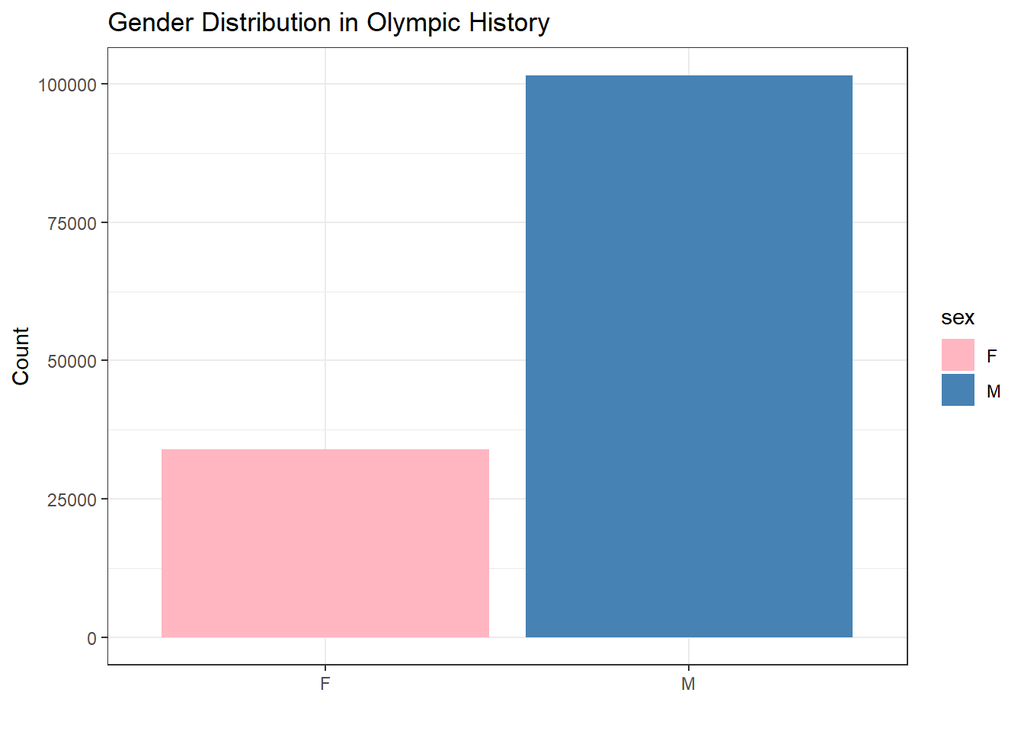

```r
olympics |>
  distinct(id, .keep_all = TRUE) |>
  group_by(sex) |>
  summarise(count = n()) |>
  ggplot(aes(x = sex, y = count, fill = sex)) +
  geom_col() +
  scale_fill_manual(values = c("lightpink", "steelblue")) +
  labs(
    title = "Gender Distribution in Olympic History",
    x = "",
    y = "Count"
  )
```

With a total of 135,571 unique Olympic competitors, 33,981 (25%) have been female and 101,590 (75%) have been male.

##### **How does the medal distribution compare between male and female athletes?**

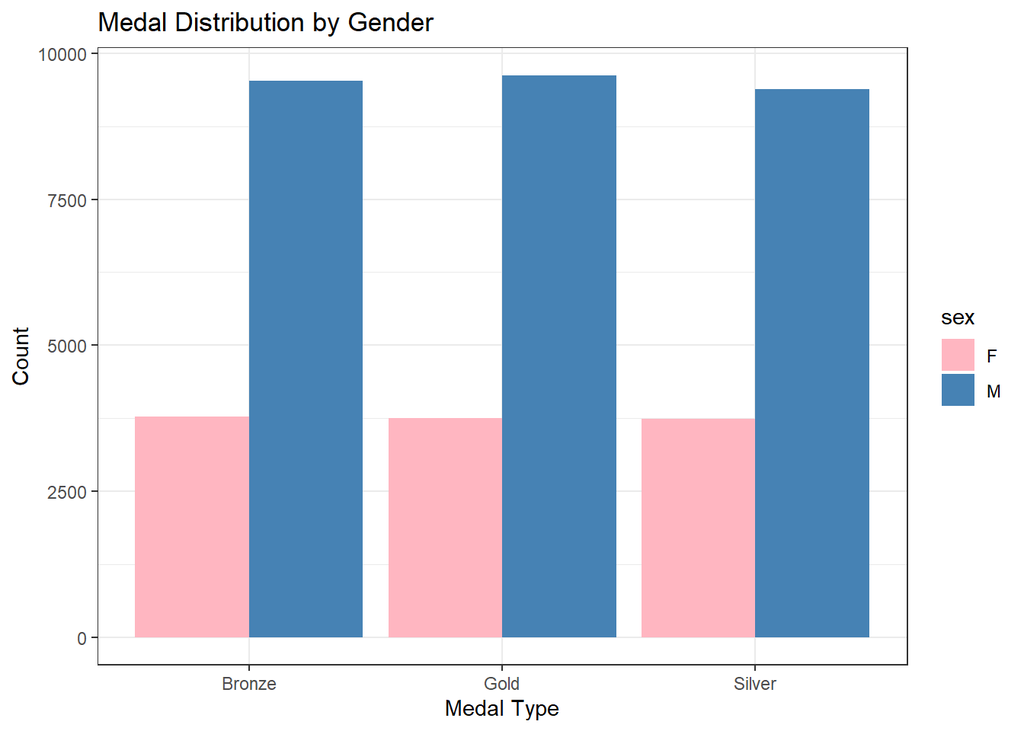

```r
olympics |>
  filter(!is.na(medal)) |>
  group_by(sex, medal) |>
  count() |>
  ungroup() |>
  ggplot(aes(x = medal, y = n, fill = sex)) +
  geom_bar(stat = "identity", position = "dodge") +
  scale_fill_manual(values = c("lightpink", "steelblue")) +
  labs(
    title = "Medal Distribution by Gender",
    x = "Medal Type",
    y = "Count"
  )
```

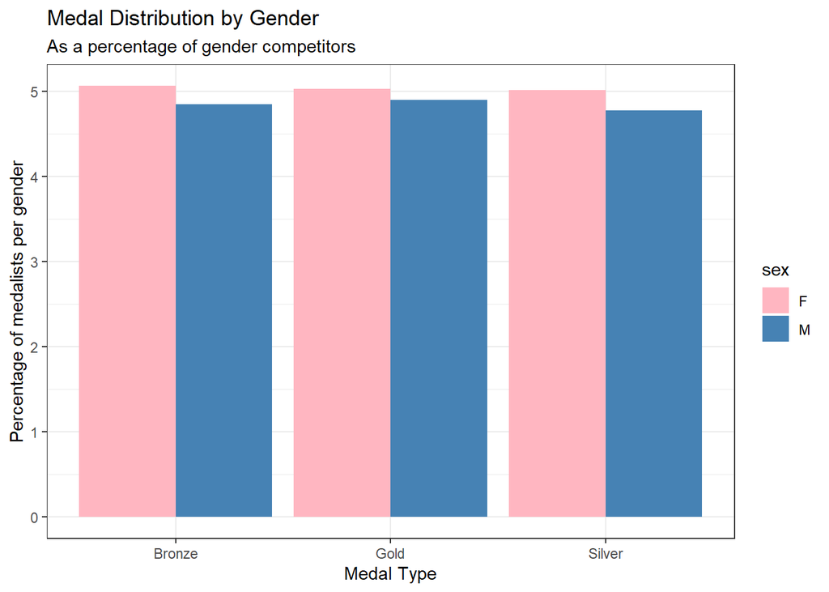

```r
#----------------------------------------

total_medalists_per_gender <- olympics |>
  filter(!is.na(medal)) |>
  group_by(sex) |>
  count(name = "total_medalists")

total_competitors_per_gender <- olympics |>
  group_by(sex) |>
  count(name = "total_competitors")

olympics |>
  filter(!is.na(medal)) |>
  group_by(sex, medal) |>
  count(name = "medal_count") |>
  ungroup() |>
  left_join(total_competitors_per_gender, by = "sex") |>
  mutate(percentage = (medal_count / total_competitors) * 100) |>
  ggplot(aes(x = medal, y = percentage, fill = sex)) +
  geom_bar(stat = "identity", position = "dodge") +
  scale_fill_manual(values = c("lightpink", "steelblue")) +
  labs(
    title = "Medal Distribution by Gender",
    subtitle = "As a percentage of gender competitors",
    x = "Medal Type",
    y = "Percentage of medalists per gender"
  )
```

##### **Are there sports where one gender tends to dominate in terms of medal count?**

```r
olympics |>
  filter(!is.na(medal)) |>
  group_by(sex, sport) |>
  summarise(total_medals = n()) |>
  arrange(sex, desc(total_medals)) |>
  ungroup() |>
  group_by(sport) |>
  mutate(total_sport_medals = sum(total_medals)) |>
  mutate(percentage_top = total_medals / total_sport_medals * 100) |>
  filter(percentage_top > 50,
         total_medals >= 10)
```

[output not shown]

There are only 3 Olympic sports in which women hold a dominant number of medals (>50%):

1. synchronized swimming
2. softball
3. rhythmic gymnastics

All 3 of these are exclusively female sporting events.

## Medals

##### **Are there certain sports where younger or older athletes tend to win more medals? What about the height or weight of the athlete?**

AGE

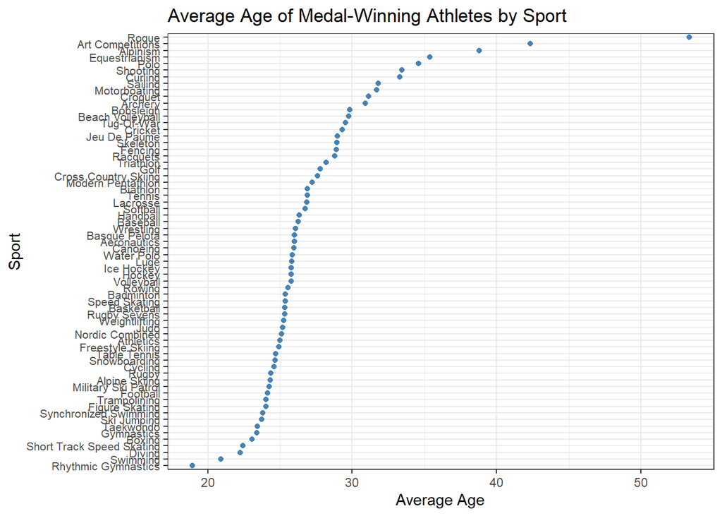

```r
olympics |>
  filter(!is.na(medal)) |>
  group_by(sport) |>
  summarise(
    avg_age = mean(age, na.rm = TRUE),
    count = n()
  ) |>
  arrange(avg_age) |>
  na.omit() |>
  ggplot(aes(x = reorder(sport, avg_age), y = avg_age)) +
  geom_point(color = "steelblue") +
  coord_flip() +
  labs(
    title = "Average Age of Medal-Winning Athletes by Sport",
    x = "Sport",
    y = "Average Age"
  ) +
  theme(axis.text.y = element_text(size = 8))
```

HEIGHT

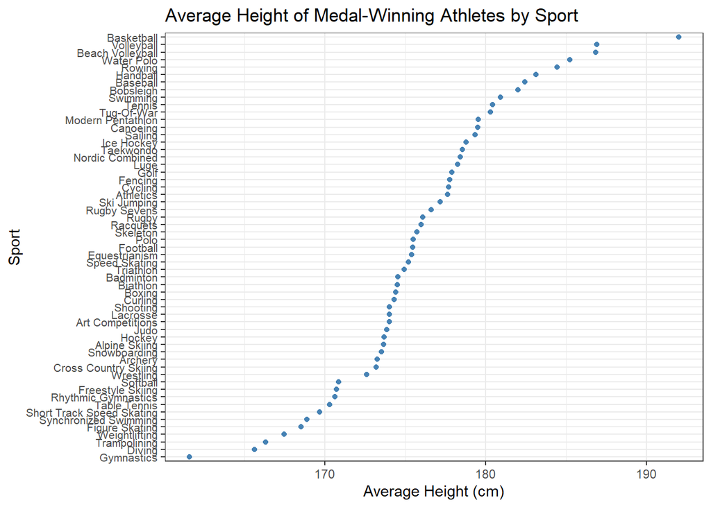

```r
olympics |>
  filter(!is.na(medal)) |>
  group_by(sport) |>
  summarise(
    avg_height = mean(height, na.rm = TRUE),
    count = n()
  ) |>
  arrange(avg_height) |>
  na.omit() |>
  ggplot(aes(x = reorder(sport, avg_height), y = avg_height)) +
  geom_point(color = "steelblue") +
  coord_flip() +
  labs(
    title = "Average Height of Medal-Winning Athletes by Sport",
    x = "Sport",
    y = "Average Height (cm)"
  ) +
  theme(axis.text.y = element_text(size = 8))
```

WEIGHT

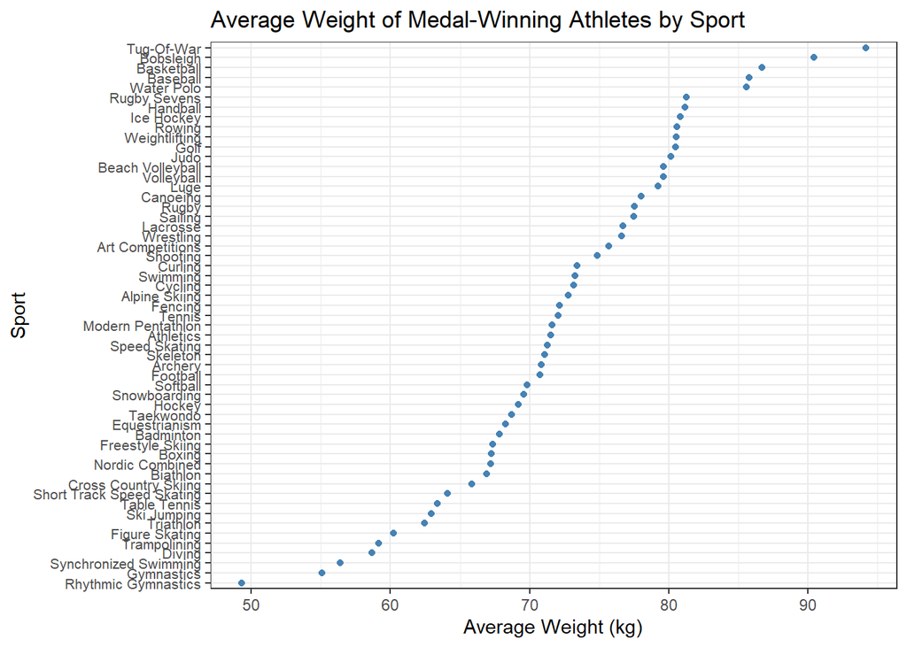

```r
olympics |>
  filter(!is.na(medal)) |>
  group_by(sport) |>
  summarise(
    avg_weight = mean(weight, na.rm = TRUE),
    count = n()
  ) |>
  arrange(avg_weight) |>
  na.omit() |>
  ggplot(aes(x = reorder(sport, avg_weight), y = avg_weight)) +
  geom_point(color = "steelblue") +
  coord_flip() +
  labs(
    title = "Average Weight of Medal-Winning Athletes by Sport",
    x = "Sport",
    y = "Average Weight (kg)"
  ) +
  theme(axis.text.y = element_text(size = 8))
```

##### **Which athlete has won the most gold medals? Silver? Bronze? Total medals?**

```r
decorated_olympians <- olympics |>
  filter(!is.na(medal)) |>
  group_by(name) |>
  summarise(gold = sum(medal == "Gold", na.rm = TRUE),
            silver = sum(medal == "Silver", na.rm = TRUE),
            bronze = sum(medal == "Bronze", na.rm = TRUE),
            total = gold + silver + bronze
  ) |>
  arrange(desc(total))

datatable(decorated_olympians)
```

|  | name | gold | silver | bronze | total |
| --- | --- | --- | --- | --- | --- |
| 1 | Michael Fred Phelps, II | 23 | 3 | 2 | 28 |
| 2 | Larysa Semenivna Latynina (Diriy-) | 9 | 5 | 4 | 18 |
| 3 | Nikolay Yefimovich Andrianov | 7 | 5 | 3 | 15 |
| 4 | Borys Anfiyanovych Shakhlin | 7 | 4 | 2 | 13 |
| 5 | Edoardo Mangiarotti | 6 | 5 | 2 | 13 |
| 6 | Ole Einar Bjrndalen | 8 | 4 | 1 | 13 |
| 7 | Takashi Ono | 5 | 4 | 4 | 13 |
| 8 | Aleksey Yuryevich Nemov | 4 | 2 | 6 | 12 |
| 9 | Birgit Fischer-Schmidt | 8 | 4 | 0 | 12 |
| 10 | Dara Grace Torres (-Hoffman, -Minas) | 4 | 4 | 4 | 12 |

[output cut: 28192 more lines]

##### **Which country/team has won the most medals overall?**

```r
decorated_countries <- olympics |>
  filter(!is.na(medal)) |>
  group_by(team) |>
  summarise(gold = sum(medal == "Gold", na.rm = TRUE),
            silver = sum(medal == "Silver", na.rm = TRUE),
            bronze = sum(medal == "Bronze", na.rm = TRUE),
            total = gold + silver + bronze
  ) |>
  arrange(desc(total))
datatable(decorated_countries)
```

|  | team | gold | silver | bronze | total |
| --- | --- | --- | --- | --- | --- |
| 1 | United States | 2529 | 1559 | 1287 | 5375 |
| 2 | Soviet Union | 1080 | 732 | 689 | 2501 |
| 3 | Germany | 721 | 651 | 711 | 2083 |
| 4 | Great Britain | 543 | 604 | 594 | 1741 |
| 5 | France | 461 | 525 | 594 | 1580 |
| 6 | Italy | 549 | 526 | 502 | 1577 |
| 7 | Sweden | 451 | 482 | 509 | 1442 |
| 8 | Australia | 344 | 453 | 513 | 1310 |
| 9 | Canada | 438 | 423 | 420 | 1281 |
| 10 | Russia | 390 | 367 | 401 | 1158 |

[output cut: 415 more lines]

The United States has the most overall medals, as well as the most gold, silver, and bronze medals individually.

##### **How does the number of medals won differ by season (Summer vs. Winter)?**

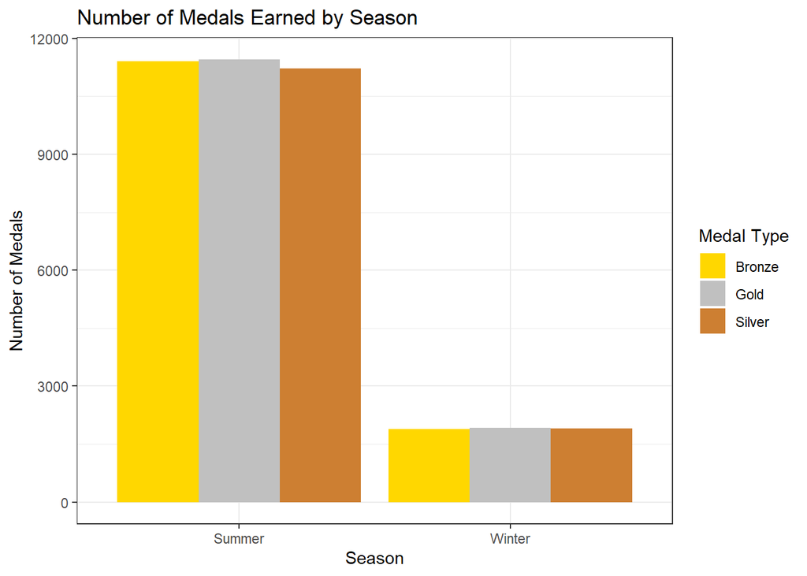

```r
olympics |>
  filter(!is.na(medal)) |>
  group_by(season, medal) |>
  count() |>
  ggplot(aes(x = season, y = n, fill = medal)) +
  geom_col(position = "dodge") +
  scale_fill_manual(values = c("#FFD700", "#C0C0C0", "#CD7F32")) +
  labs(
    title = "Number of Medals Earned by Season",
    x = "Season",
    y = "Number of Medals",
    fill = "Medal Type"
  )
```

##### **Which sport has the highest number of medals awarded?**

```r
sport_medals <- olympics |>
  filter(!is.na(medal)) |>
  group_by(sport) |>
  summarise(gold = sum(medal == "Gold", na.rm = TRUE),
            silver = sum(medal == "Silver", na.rm = TRUE),
            bronze = sum(medal == "Bronze", na.rm = TRUE),
            total = gold + silver + bronze
  ) |>
  arrange(desc(total))

datatable(sport_medals)
```

|  | sport | gold | silver | bronze | total |
| --- | --- | --- | --- | --- | --- |
| 1 | Athletics | 1339 | 1334 | 1296 | 3969 |
| 2 | Swimming | 1099 | 993 | 956 | 3048 |
| 3 | Rowing | 978 | 977 | 990 | 2945 |
| 4 | Gymnastics | 791 | 746 | 719 | 2256 |
| 5 | Fencing | 594 | 583 | 566 | 1743 |
| 6 | Football | 515 | 513 | 543 | 1571 |
| 7 | Ice Hockey | 508 | 515 | 507 | 1530 |
| 8 | Hockey | 518 | 498 | 512 | 1528 |
| 9 | Wrestling | 413 | 415 | 468 | 1296 |
| 10 | Cycling | 424 | 425 | 414 | 1263 |

[output cut: 56 more lines]

## Performance Over Time

**How has the distribution of medals changed over time?**

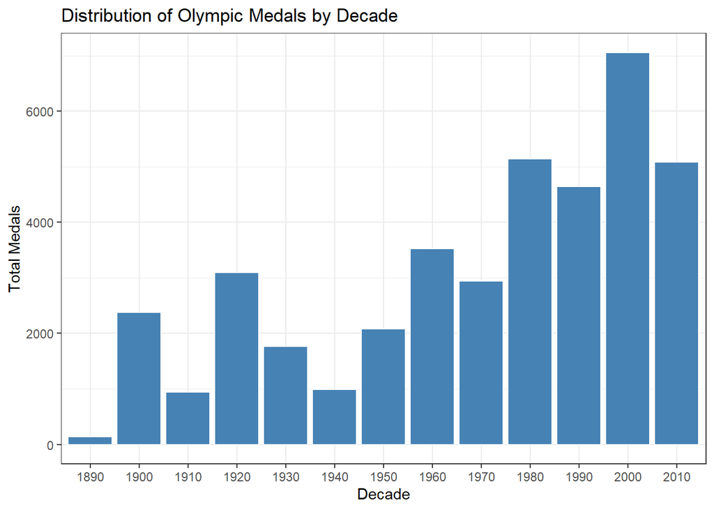

```r
#grouped by decade
olympics |>
  filter(!is.na(medal)) |>
    mutate(decade = (year %/% 10) * 10) |>
  group_by(decade) |>
  summarise(total_medals = n()) |>
  arrange(decade, desc(total_medals)) |>
  ggplot(aes(x = factor(decade), y = total_medals)) +
  geom_bar(stat = "identity", position = "stack", color = "white", fill = "steelblue") +
  labs(
    title = "Distribution of Olympic Medals by Decade",
    x = "Decade",
    y = "Total Medals"
  ) +
  theme(legend.position = "none")
```

**Are there trends in certain countries dominating specific sports over time?**

```r
domination <- olympics |>
  filter(!is.na(medal)) |>
  group_by(team, sport) |>
  summarise(total_medals = n()) |>
  arrange(sport, desc(total_medals)) |>
  ungroup() |>
  group_by(sport) |>
  mutate(total_sport_medals = sum(total_medals)) |>
  mutate(percentage_top = total_medals / total_sport_medals * 100) |>
  filter(percentage_top >= 25,
         total_medals >= 10)
```

The table below lists which countries have dominated specific sporting events in the Olympics (*along with the number of medals it’s won*). A country is considered “dominant” if it has:

1. won at least 10 medals in that sport
2. won more than 25% of the total medals in that sport

| Sport | Dominant Country | Second Dominant (*if applicable*) |
| --- | --- | --- |
| Alpine Skiing | Austria (*114*) |  |
| Alpinism | Great Britain (*12*) |  |
| Athletics | United States (*1,071*) |  |
| Badminton | China (*64*) |  |
| Baseball | Cuba (*112*) |  |
| Basketball | United States (*341*) |  |
| Beach Volleyball | Brazil (*26*) | United States (*20*) |
| Cricket | Great Britain (*12*) | France (*12*) |
| Curling | Canada (*48*) |  |
| Diving | United States (*140*) |  |
| Luge | Germany (*47*) |  |
| Racquets | Great Britain (*10*) |  |
| Rhythmic Gymnastics | Russia (*45*) |  |
| Short Track Speed Skating | South Korea (*73*) |  |
| Snowboarding | United States (*24*) |  |
| Softball | Australia (*60*) | United States (*60*) |
| Swimming | United States (*1,066*) |  |
| Synchronized Swimming | Russia (*54*) |  |
| Table Tennis | China (*81*) |  |
| Trampolining | China (*11*) |  |

##### **How has the age of all Olympians changed over time?**

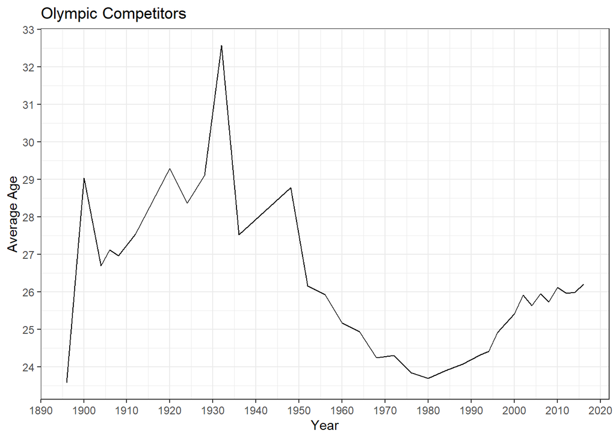

```r
age <- olympics |>
  group_by(year) |>
  summarise(avg_age = mean(age, na.rm = TRUE))

ggplot(age, aes(x = year, y = avg_age)) +
  geom_line() +
  labs(
    title = "Olympic Competitors",
    x = "Year",
    y = "Average Age"
  ) +
  scale_x_continuous(breaks = seq(1890, 2020, by = 10)) +
  scale_y_continuous(breaks = seq(20, 33, by = 1))
```

##### **Has the average age of medal-winning athletes changed over the years?**

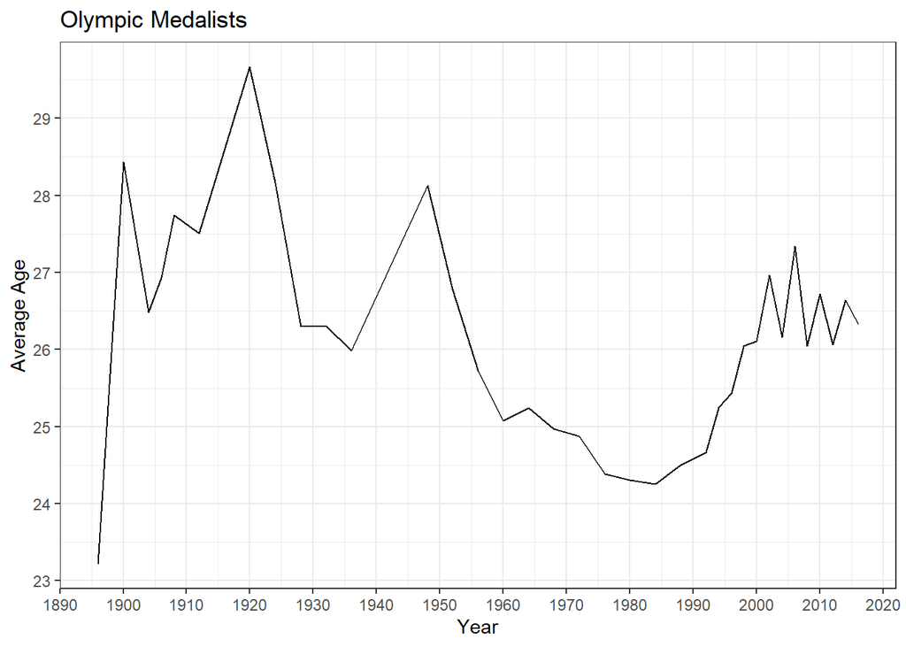

```r
age_winners <- olympics |>
  filter(!is.na(medal)) |>
  group_by(year) |>
  summarise(avg_age = mean(age, na.rm = TRUE))

ggplot(age_winners, aes(x = year, y = avg_age)) +
  geom_line() +
   labs(
    title = "Olympic Medalists",
    x = "Year",
    y = "Average Age"
  ) +
  scale_x_continuous(breaks = seq(1890, 2020, by = 10)) +
  scale_y_continuous(breaks = seq(20, 30, by = 1))
```

## Predictive Models

**Athletics Medal Prediction Model**: Predict whether an athlete will win a medal based on age, height, weight, team, and sport.

```r
athletics <- olympics |>
  filter(sport == "Athletics") |>
  mutate(medal_binary = ifelse(!is.na(medal), 1, 0))

cor(athletics$medal_binary, athletics$age, use = "complete.obs")
cor(athletics$medal_binary, athletics$height, use = "complete.obs")
cor(athletics$medal_binary, athletics$weight, use = "complete.obs")
```

[output not shown]

```r
athletics <- olympics |>
  filter(sport == "Athletics") |>
  mutate(medal_binary = ifelse(!is.na(medal), 1, 0))

model_athletics <- lm(medal_binary ~ age + height + weight + team, data = athletics)

tidy(model_athletics, conf.int = TRUE) |>
  filter(!str_starts(term, "team"))
```

```
# A tibble: 4 × 7
  term          estimate std.error statistic p.value  conf.low conf.high
  <chr>            <dbl>     <dbl>     <dbl>   <dbl>     <dbl>     <dbl>
1 (Intercept)  0.00501    0.0840      0.0596 0.952   -0.160     0.170
2 age         -0.00117    0.000390   -3.00   0.00266 -0.00194  -0.000407
3 height      -0.0000415  0.000280   -0.148  0.882   -0.000590  0.000507
4 weight       0.000433   0.000168    2.57   0.0100   0.000104  0.000763
```

```r
glance(model_athletics)
```

```
# A tibble: 1 × 12
  r.squared adj.r.squared sigma statistic p.value    df logLik    AIC    BIC
      <dbl>         <dbl> <dbl>     <dbl>   <dbl> <dbl>  <dbl>  <dbl>  <dbl>
1     0.110         0.104 0.299      17.4       0   229 -6775. 14011. 15948.
# ℹ 3 more variables: deviance <dbl>, df.residual <int>, nobs <int>
```

**Country Medal Count Forecasting**: Predict the total number of medals a country will win in a future Olympics.

```r
country_medals <- olympics |>
  filter(!is.na(medal)) |>
  mutate(team = case_when(
    team %in% c("United States Golf Association-3", "United States Virgin Islands", "United States-1", "United States-2", "United States-3", "United States-4") ~ "United States",
    TRUE ~ team
  )) |>
  group_by(team, year) |>
  summarise(total_medals = n(),
            .groups = "drop")

# Aggregate additional features by country and year
country_features <- olympics |>
  group_by(team, year) |>
  summarise(
    num_athletes = n(),
    avg_age = mean(age, na.rm = TRUE),
    avg_height = mean(height, na.rm = TRUE),
    avg_weight = mean(weight, na.rm = TRUE),
    .groups = "drop"
  )

# Merge features with medal counts
country_data <- country_medals |>
  left_join(country_features, by = c("team", "year"))

# Fit a linear regression model
model_medal_count_forecast <- lm(total_medals ~ num_athletes, data = country_data)

# Summary of the model
summary(model_medal_count_forecast)
```

```
Call:
lm(formula = total_medals ~ num_athletes, data = country_data)

Residuals:
    Min      1Q  Median      3Q     Max
-109.72  -10.09    1.38    8.66  337.19

Coefficients:
              Estimate Std. Error t value Pr(>|t|)
(Intercept)  -6.285309   0.786049  -7.996 2.34e-15 ***
num_athletes  0.209241   0.003618  57.829  < 2e-16 ***
---
Signif. codes:  0 '***' 0.001 '**' 0.01 '*' 0.05 '.' 0.1 ' ' 1

Residual standard error: 24.81 on 1715 degrees of freedom
Multiple R-squared:  0.661, Adjusted R-squared:  0.6608
F-statistic:  3344 on 1 and 1715 DF,  p-value: < 2.2e-16
```

```r
# Predict medals for a future Olympics (e.g., 2028)
new_data <- data.frame(
  num_athletes = c(592)
)

predicted_medals <- predict(model_medal_count_forecast, newdata = new_data)
predicted_medals
```

```
       1
117.5855
```